# Reproducible Research: Peer Assessment 1

### Loading and preprocessing the data

First, we need to load the data. We assume that the file is already downloaded. Also, we assume that it is located in the working directory. Then we convert date values to *date* format.

```r
unzip("activity.zip")
data <- read.csv("activity.csv")
data$Date<-as.Date(data$date, format="%Y-%m-%d")
```

### What is mean total number of steps taken per day?

Now we need to calculate the total number of steps taken per day. We will use *aggregate* function for this task.

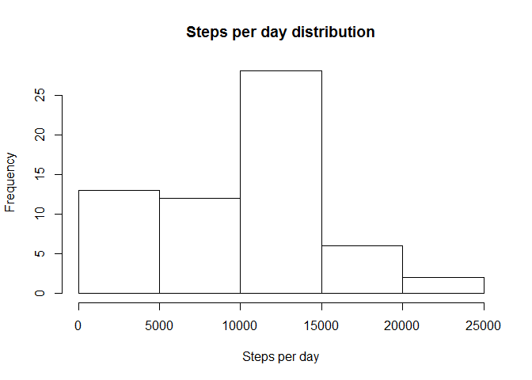

```r
agg.date <- aggregate(x=data$steps, by=list(data$Date), FUN=sum, na.rm=TRUE)
names(agg.date) <- c("Date", "steps")
hist(agg.date$steps, xlab="Steps per day", main="Steps per day distribution")
```

Then we take mean and median of daily values:

```r
mean(agg.date$steps)
```

```
## [1] 9354.23
```

```r
median(agg.date$steps)
```

```
## [1] 10395
```

### What is the average daily activity pattern?

Now let’s look at how the number if steps changes during a day (we take interval averages for all days). Intervals are converted to *time*.

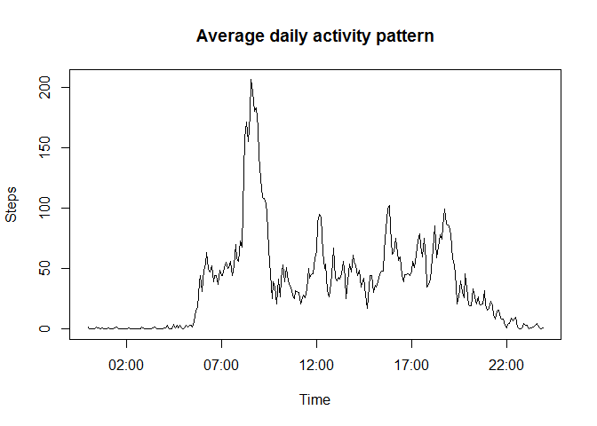

```r
agg.interval <- aggregate(x=data$steps, by=list(data$interval), FUN=mean, na.rm=TRUE)
names(agg.interval)=c("interval", "steps")
agg.interval$steps <- round(agg.interval$steps)
library(lubridate)
agg.interval$time<-parse_date_time(agg.interval$interval, c("%H%M", "%M"))
plot(agg.interval$time, agg.interval$steps, type="l", ylab="Steps", xlab="Time", main="Average daily activity pattern")
```

Next task is to find the largest number of steps and determine when it happened.

```r
max <- which.max(agg.interval$steps)
max
```

```
## [1] 104
```

```r
max.interval <- agg.interval[max, 1]
max.interval
```

```
## [1] 835
```

```r
max.steps <- agg.interval[max, 2]
max.steps
```

```
## [1] 206
```

As we see, maximum number of steps is 206 and it occurs at 835 interval.

### Imputing missing values

Let’s check whether we have missing values in our dataset.

```r
sum(is.na(data$steps))
```

```
## [1] 2304
```

Since we do have missing values, let’s replace them with a mean for respective interval.

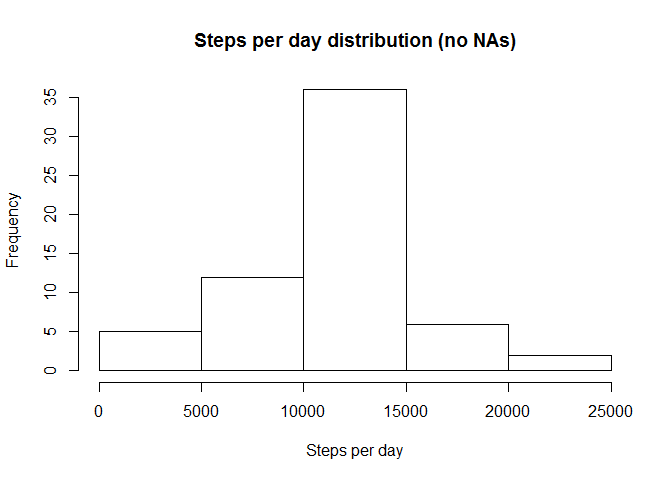

```r
data.na <- data
agg.na <- aggregate(x=data$steps, by=list(data$interval), FUN=mean, na.rm=TRUE)
for (i in 1:nrow(data.na))
    {
    if (is.na(data.na[i, 1]))
        {
        data.na[i, 1] <- round(agg.na$x[agg.na$Group.1==data.na[i, 3]])
        }
    }
agg.na.date <- aggregate(x=data.na$steps, by=list(data.na$Date), FUN=sum)
names(agg.na.date) <- c("Date", "steps")
hist(agg.na.date$steps, xlab="Steps per day", main="Steps per day distribution (no NAs)")
```

Again, we take mean and median of daily values:

```r
mean(agg.na.date$steps)
```

```
## [1] 10765.64
```

```r
median(agg.na.date$steps)
```

```
## [1] 10762
```

### Are there differences in activity patterns between weekdays and weekends?

```r
Sys.setlocale("LC_TIME", "US")
```

```
## [1] "English_United States.1252"
```

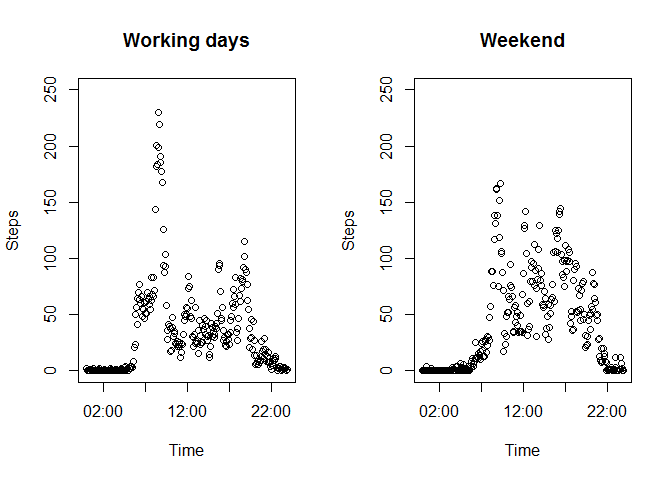

```r
data.na$weekend <-ifelse((weekdays(data.na$Date)=="Saturday" | weekdays(data.na$Date)=="Sunday"), 1, 0)
workday<-data.na[data.na$weekend==0, ]
weekend<-data.na[data.na$weekend==1, ]

agg.workday <-aggregate(x=workday$steps, by=list(workday$interval), FUN=mean)
names(agg.workday) <- c("interval", "steps")
agg.workday$time<-parse_date_time(agg.workday$interval, c("%H%M", "%M"))

agg.weekend <-aggregate(x=weekend$steps, by=list(weekend$interval), FUN=mean)
names(agg.weekend) <- c("interval", "steps")
agg.weekend$time<-parse_date_time(agg.weekend$interval, c("%H%M", "%M"))

par(mfrow=c(1,2))
plot(agg.workday$time, agg.workday$steps, ylim=c(0, 250), xlab="Time", ylab="Steps", main="Working days")
plot(agg.weekend$time, agg.weekend$steps, ylim=c(0, 250), xlab="Time", ylab="Steps", main="Weekend")
```

We can see that activity distribution during a day differs on type of a day. On working days people get up earlier, then commute (some part of commuting is walking), walk a bit during their work, then get back home (in the evening they are tired that’s walk less and take public transportaion). During weekend, people get up later, walk a lot during a day, and the distribution of activity is more even. Local minima are probably associated with meals.